# Mafia Acoustics Paper - Data Analysis

Fernando Cagua

9 September 2014

# Preprocessing

## Acoustic data

We first import the all files that contain the data we want to work with. That includes the csv containing the raw detections as exported by VUE, the receiver events file (from VUE), the array events file and the list of whale sharks tagged. And the list with sharks known to have lost their tag.

```r
# Read CSV detection file and process it with VTrack
MAFIA.DETECTIONS <- ReadInputData (
  read.csv ("../Raw Data/AllMafiaDetections20140715.csv"),
  iHoursToAdd = 3)
MAFIA.DETECTIONS$DATETIME <- as.POSIXct (
  as.POSIXlt (MAFIA.DETECTIONS$DATETIME, tz="Africa/Dar_es_Salaam"))

RECEIVER.EVENTS <- read.csv ("../Raw Data/AllMafiaEvents20140715.csv")
ARRAY.EVENTS <- read.csv ("../Raw Data/ArrayEvents_20140808.csv")
WS.TAGS <- read.csv ("../Raw Data/WSTags_20140909.csv")

TAG.LOST <- data.frame (id = c ("X","TZ-030", "TZ-068", "TZ-040", "TZ-032"),
                        date = as.Date (c ("2012-10-26","2013-10-14", "2013-12-21", "2014-01-07", "2014-01-09")))
```

### Correct time drift

We also correct for time drift using the events exported from VUE. It is necessary to check manually that all entries are correct, i.e. to check that all the time zones were correctly set up. We found four inconsistencies.

```r
# Read CSV events file

names (RECEIVER.EVENTS) <- c ("DATETIME", "RECEIVERID", "DESC", "DATA", "UNITS")
RECEIVER.EVENTS$DATETIME <- as.POSIXct (RECEIVER.EVENTS$DATETIME, tz ="UTC")
RECEIVER.EVENTS$DATETIME <- as.POSIXct (
  as.POSIXlt (RECEIVER.EVENTS$DATETIME, tz="Africa/Dar_es_Salaam"))
PC.TIMES <- RECEIVER.EVENTS [RECEIVER.EVENTS$DESC == "PC Time", c (1, 2, 4)]
# We manually checked that all PC times are in the time-zone GMT+3 so we can go ahead and convert the PC times to POSIXct class
PC.TIMES$DATA <- as.POSIXct (
  substr (as.character (PC.TIMES$DATA), 1, 19), tz="Africa/Dar_es_Salaam")

# # Plots to check for time zone and computer time mistakes
# ggplot(PC.TIMES) + geom_line (aes (x = DATA, y = as.vector (DATA - DATETIME)/60)) + facet_grid (. ~ RECEIVERID , scale = "fixed")
# U <- PC.TIMES[PC.TIMES$RECEIVERID == "VR2W-104845", ]
# V <- data.frame (DATETIME = seq (min(U$DATETIME), max(U$DATETIME), "week"), DIFF = approx (as.numeric(U$DATA), as.vector (U$DATA - U$DATETIME), seq (min(U$DATETIME), max(U$DATETIME), "week")))
# ggplot

# Error for Data Upload on 2013-01-27 09:21:07 (receiver time) for VR2W-104847
PC.TIMES$DATA[PC.TIMES$DATETIME == as.POSIXct ("2013-01-27 09:21:07")] <- PC.TIMES$DATA[PC.TIMES$DATETIME == as.POSIXct ("2013-01-27 09:21:07")] + 3600*3
# Error for Data Upload on 2013-01-22 11:37:46 (receiver time) for VR2W-104848
PC.TIMES$DATA[PC.TIMES$DATETIME == as.POSIXct ("2013-01-22 11:37:46")] <- PC.TIMES$DATA[PC.TIMES$DATETIME == as.POSIXct ("2013-01-22 11:37:46")] + 3600*3
# Error for Data Upload on 2013-01-27 08:12:34 (receiver time) for VR2W-109044
PC.TIMES$DATA[PC.TIMES$DATETIME == as.POSIXct ("2013-01-27 08:12:34")] <- PC.TIMES$DATA[PC.TIMES$DATETIME == as.POSIXct ("2013-01-27 08:12:34")] + 3600*3
# Error for Data Upload on 2013-01-27 07:42:54 (receiver time) for VR2W-113484
PC.TIMES$DATA[PC.TIMES$DATETIME == as.POSIXct ("2013-01-27 07:42:54")] <- PC.TIMES$DATA[PC.TIMES$DATETIME == as.POSIXct ("2013-01-27 07:42:54")]  + 3600*3

# Correct time drift
receiverIDs <- levels (MAFIA.DETECTIONS$RECEIVERID)
#pb <- txtProgressBar(max=length (receiverIDs), style = 3)
for (i in 1:length (receiverIDs)){
  #setTxtProgressBar (pb, i)
  receiver.PC.TIMES <- PC.TIMES[PC.TIMES$RECEIVERID == receiverIDs[i], ]
  drift <- approx (receiver.PC.TIMES$DATA, receiver.PC.TIMES$DATA - receiver.PC.TIMES$DATETIME, MAFIA.DETECTIONS[MAFIA.DETECTIONS$RECEIVERID == receiverIDs[i], ]$DATETIME)$y
  MAFIA.DETECTIONS[MAFIA.DETECTIONS$RECEIVERID == receiverIDs[i], ]$DATETIME <- MAFIA.DETECTIONS[MAFIA.DETECTIONS$RECEIVERID == receiverIDs[i], ]$DATETIME + drift
}
#close (pb)
```

### Assign detections to stations

In order to assign detections to stations we import a table containing a list of the times when a receiver was deployed or retrieved and where. Each detection is then assigned to a particular station (location) as opposed to a specific receiver. This procedure automatically takes out detections that occurred when receivers were outside of the water.

```r
# Read and organize events (retrievals/deployments) data
ARRAY.EVENTS <- ARRAY.EVENTS[(ARRAY.EVENTS$EVENT == "DEP") | (ARRAY.EVENTS$EVENT == "RET"), ]
R.EVE <- data.frame(DATETIME = as.POSIXct (ARRAY.EVENTS$DATE, tz="Africa/Dar_es_Salaam"))
R.EVE$STATIONNAME <- factor(ARRAY.EVENTS$STATION)
R.EVE$EVENT <- ARRAY.EVENTS$EVENT
R.EVE$RECEIVERID <- ARRAY.EVENTS$REC
ARRAY.EVENTS <- R.EVE

# Read stations file and assign detections to stations
STATIONS <- read.csv ("../Raw Data/Stations_20130205.csv")
# Assign station and location
#pb <- txtProgressBar(max=length (ARRAY.EVENTS [,1]), style = 3)
for (i in 1:length (ARRAY.EVENTS [,1])){  # For each event
  # If is a deployment change the station for the future
  if (ARRAY.EVENTS$EVENT[i] == "DEP"){
    # message ("    Analyzing deployment of ", ARRAY.EVENTS$RECEIVERID[i], " on ",
    #         floor_date (ARRAY.EVENTS$DATETIME[i], "day"), " at   Station ", ARRAY.EVENTS$STATIONNAME[i])
    replace.index <- (as.character (ARRAY.EVENTS$RECEIVERID[i]) == as.character(MAFIA.DETECTIONS$RECEIVERID)) & (MAFIA.DETECTIONS$DATETIME >= ARRAY.EVENTS$DATETIME[i])
    # Include station
    MAFIA.DETECTIONS$STATIONNAME [replace.index] <- as.character (ARRAY.EVENTS$STATIONNAME[i])
  }
  # If is a retrieval delete data for the future
  else {
    # message ("    Analyzing retrieval  of ", ARRAY.EVENTS$RECEIVERID[i], " on ",
    #        floor_date (ARRAY.EVENTS$DATETIME[i], "day"), " from Station ", ARRAY.EVENTS$STA[i])
    replace.index <- (as.character (ARRAY.EVENTS$RECEIVERID[i]) == as.character(MAFIA.DETECTIONS$RECEIVERID)) &
      (MAFIA.DETECTIONS$DATETIME >= ARRAY.EVENTS$DATETIME[i])
    MAFIA.DETECTIONS$STATIONNAME[replace.index] <- NA
  }
  #setTxtProgressBar (pb, i)
}
#close (pb)
# Delete detections outside valid intervals
MAFIA.DETECTIONS <- MAFIA.DETECTIONS[MAFIA.DETECTIONS$STATIONNAME != 'Unknown' & !is.na (MAFIA.DETECTIONS$STATIONNAME), ]

save (MAFIA.DETECTIONS, ARRAY.EVENTS, file ="../Processed Data/AllDetections.RData")
rm (R.EVE, i, replace.index)
```

### Filter detections

Here we filter out only whale shark tags (discarding range test, foreign and collisions). I use the list of tagged sharks for that. Simultaneously, to prevent the analysis of potentially un-natural behavior the first 48 hours of detections are removed. It also assigns a unique whale shark ID to each transmitter ID.

```r
# Read file with Whale Shark Tag lists
WS.TAGS$DATE <- as.POSIXct (WS.TAGS$DATE, format="%d/%m/%Y", tz = "Africa/Dar_es_Salaam")
WS.TAGS$NAME <- WS.TAGS$COMMENT <- WS.TAGS$SHARK <- NULL

# Select only whale shark detections
DET.WS <- MAFIA.DETECTIONS[!is.na (match (MAFIA.DETECTIONS$TRANSMITTERID, WS.TAGS$TRANSMITTERID)), ]

# Remove detections before 48 hours after tagging date
for (i in 1: nrow(WS.TAGS)){
  next2.days <- WS.TAGS$DATE + 60 * 60 * 24 * 2  # Add two days
  replace.index <- as.character (DET.WS$TRANSMITTERID) == as.character (WS.TAGS$TRANSMITTERID[i])
  # Delete rows that are in the tagging day
  DET.WS <- subset (DET.WS, ! (replace.index & (DET.WS$DATETIME < next2.days[i])))
}

# Remove unused tags from the factor list
DET.WS$TRANSMITTERID <- factor (DET.WS$TRANSMITTERID)
rm (i, next2.days, replace.index)
```

### Foreign tags

Remove range test tags and whale shark tags. There was an “abbandoned” tag in fron of K11 for a long time. We’ll remove it. Also Because some of them might be colissions, we’ll discard any with less than two detections

```r
range.test.tags <- read.csv ("../Raw Data/RTTags_20130305.csv")
DET.RT <- filter (MAFIA.DETECTIONS, TRANSMITTERID %in% range.test.tags$Transmitter)

ddet.ws <- filter (MAFIA.DETECTIONS, TRANSMITTERID %in% WS.TAGS$TRANSMITTERID)
foreign.detections <- anti_join (MAFIA.DETECTIONS, ddet.ws) %>%
  anti_join (DET.RT) %>%
  filter (TRANSMITTERID != "A69-1303-53872") %>%
  select (-(STATIONNAME)) %>%
  ddply ("TRANSMITTERID", function (x){
  if (nrow (x) > 1) {
    return (x)
  } else {
    return (NULL)
    }
})
foreign.detections$TRANSMITTERID <- factor (foreign.detections$TRANSMITTERID)
```

# Residency models

The follwing function calculates both a time and a lag dependent response variable for the precense of whale sharks.

```r
# Function to calculate the vectors of presence absence
pres.abs.lag <- function (start.date, end.date, sightings, dates){
  # Create a data frame with the detections
  sight <- data.frame (id = sightings, date = dates) %>%
    filter (date >= start.date, date <= end.date) %>%
    mutate (id = factor (id)) %>%
    arrange (date)

  # For each shark we'll start with the first detection only
  individuals <- levels (sight$id)
  # Cycle trough each shark
  presence.absence <- foreach (i=1:length (individuals),
                               .combine = rbind) %dopar% {
    # Find dates in which the shark was present
    dates.present <- sight$date[sight$id == individuals[i]] %>%
      as.numeric ()
    # Establish all dates in which it was tagged (only dates in which there was monitoring)
    dates.tagged <- unique(sight$date)[unique(sight$date) >
                                         sight$date[match (individuals[i], sight$id)]]
    # Find all possible combinations of dates in which it was tagged
    dates.comb <- as.data.frame (t (combn (dates.tagged, 2))) %>%
      tbl_df()
    names (dates.comb) <- c ("date.1", "date.2")
    dates.comb <- mutate (dates.comb, lag = date.2 - date.1, # Find the lag between given dates
                          # Establish if it was present for in that lag
                          present = (date.1 %in% dates.present) &
                            (date.2 %in% dates.present),
                          date = as.Date(date.1, origin = "1970-01-01"),
                          id = individuals[i]) %>%
      select (-date.1, -date.2)
    return (dates.comb)
  } %>%
    mutate (day = yday (date), week = week (date), month = month(date))
  return (presence.absence)
}
```

The model was previously run in a daily basis, however the size of the resulting data frame was too large to be computationally manegable at the scales we are able to work. It will now be redone using weekly bins.

Note that Emmental TZ-003 was tagged twice, but lost it’s first tag leaving no detections

```r
det.ws <- tbl_df (DET.WS)  # Convert to tbl data frame
ws.tags <- tbl_df (WS.TAGS)
names (det.ws) <- names (det.ws) %>% tolower ()  # change names to lower case
names (ws.tags) <- names (ws.tags) %>% tolower ()
names (ws.tags)[2] <- "date.tag"

# Using only sharks present in the list of tagged sharks merge data frames
det.ws <- inner_join (det.ws, select (ws.tags, -(size), -(number)))
# Clump in a weekly basis
det.ws <- mutate (det.ws, date.week = cut (datetime, 'week') %>% as.Date ())
aco.week <- ddply (det.ws, "date.week", function (det){
  sharks <- !duplicated (det$ecocean)
  per.week <- data.frame (ecocean = det$ecocean[sharks],
                          sex = det$sex[sharks],
                          batch = det$sex[sharks],
                          date.tag = det$date.tag[sharks])
})
```

Now we calculate the response variable:

```r
PADet.comb <- pres.abs.lag (start.date = min (aco.week$date.week),
                            end.date = max (aco.week$date.week),
                            sightings = aco.week$ecocean,
                            dates = aco.week$date.week)
names (PADet.comb)[4] <- "ecocean"
```

We want to include in the model sex, size and the number of stations to control for effort.

```r
calc.nStations <- function (ARRAY.EVENTS, PADet){
  # Calculate number of receivers working
  ARRAY.EVENTS <- arrange (ARRAY.EVENTS, DATETIME)
  times.in <- ddply (ARRAY.EVENTS, "STATIONNAME", function (x){
    deployed <- filter (x, EVENT == "DEP", lead (EVENT) == "RET")
    retrieved <- filter (x, EVENT == "RET", lag (EVENT) == "DEP")
    if (nrow (deployed) > 0) {
      y <- data.frame (station = first (x$STATIONNAME),
                       date.in = deployed$DATETIME,
                       date.out = retrieved$DATETIME,
                       rec.in = deployed$RECEIVERID,
                       rec.out = retrieved$RECEIVERID)
      return (y)
    } else return (NULL)
  })
  # Calculate array configuration and number of receivers working
  PADet <- ddply (PADet, "date", function (x, times.in){
    stations.listening <- filter (times.in, x$date[1] >= as.Date (date.in), x$date[1] <= as.Date (date.out)) %>%
      select (station) %>%
      unique()
    x$configuration <- do.call (paste, as.list(stations.listening$station))
    x$nStations <- nrow (stations.listening)
    return (x)
  }, times.in = times.in)
}
```

```r
# Merge with tagged shark information
PADet.comb <- left_join (PADet.comb, select(ws.tags, ecocean, sex, size, batch))
# Generate a times in out data frame for each receiver
  ARRAY.EVENTS <- arrange (ARRAY.EVENTS, DATETIME)
  times.in <- ddply (ARRAY.EVENTS, "STATIONNAME", function (x){
    deployed <- filter (x, EVENT == "DEP", lead (EVENT) == "RET")
    retrieved <- filter (x, EVENT == "RET", lag (EVENT) == "DEP")
    if (nrow (deployed) > 0) {
      y <- data.frame (station = first (x$STATIONNAME),
                       date.in = deployed$DATETIME,
                       date.out = retrieved$DATETIME,
                       rec.in = deployed$RECEIVERID,
                       rec.out = retrieved$RECEIVERID)
      return (y)
    } else return (NULL)
  })

pres <- ddply (PADet.comb, "date", function (x, times.in){
  # Generate weekly approximations
  times.in <- mutate (times.in, w.date.in = cut (date.in, 'week'),
                      w.date.out = cut (date.out, 'week'))
    stations.listening <- filter (times.in, x$date[1] >= as.Date (w.date.in), x$date[1] <= as.Date (w.date.out)) %>%
      select (station) %>%
      unique()
  y <- data.frame (configuration = do.call (paste, as.list(stations.listening$station)),
                   nStations = nrow (stations.listening))
    return (y)
  }, times.in = times.in)

PADet.comb <- inner_join (PADet.comb, pres)
```

Now we remove the data of sharks that were known to lost their tags

```r
# Delete data for sharks that were known to loose their tag
PADet.comb <- ddply (PADet.comb, "ecocean", function (x, TAG.LOST){
  for (i in 1:length (levels (TAG.LOST$id))){
    if (as.character (TAG.LOST$id[i]) == as.character (first (x$ecocean))){
      out <- filter (x, date < TAG.LOST$date[i])
      } else {out <- x}
    }
  return (out)
  }, TAG.LOST = TAG.LOST) %>% tbl_df()

PADet.comb <- mutate (PADet.comb, lagl = log (lag + 1),
                      date.id = paste (date, ecocean))
```

Now we try the models

```r
mdA <- vector ("list", 0)

mdA[[1]] <- expression(md01 <- gamm (formula = formula (present ~ s (week, bs = "cc") + s (lag, bs = "cr") + sex + size + nStations), data = PADet.comb, family = "binomial", gamma = 1.4))

eval(mdA[[1]])
#
# # Save the residuals
# rd01 <- residuals (md01$gam, type = "pearson")
# # Plot residuals against variables
# ggplot (PADet.comb) + geom_boxplot (aes (y = rd01, x = ecocean))
# # Evidence of heteogeneous variance per shark
# ggplot (PADet.comb) + geom_boxplot (aes (y = rd01, x = batch))
# # Evidence of heterogeneous variance per batch
# ggplot (PADet.comb) + geom_boxplot (aes (y = rd01, x = as.factor(date))) + coord_flip()
# # Evidence of heterogeneous variance per start date
# ggplot (PADet.comb) + geom_boxplot (aes (y = rd01, x = as.factor(date))) + coord_flip()
# PARes <- PADet.comb ; PARes$res <- md01
```

Secondly we try a model with different smoothers per cohort

```r
# Create dummy variables per cohort
PADet.comb <- mutate (PADet.comb, B1 = 0, B2 = 0, B3= 0)
PADet.comb$B1[PADet.comb$batch == "2012-1"] <- 1
PADet.comb$B2[PADet.comb$batch == "2012-2"] <- 1
PADet.comb$B3[PADet.comb$batch == "2014-1"] <- 1
```

```r
# Only yearly pattern (ITS SINGULAR)
# mdA[[2]] <- expression (md02 <- gamm (formula = formula (present ~ s (week, bs = "cc") + s (week, bs ="cc", by = B1) + s (week, bs ="cc", by = B2) + s (week, bs ="cc", by = B3) + s (lag, bs = "cr") + sex + size + nStations), data = PADet.comb, family = "binomial", gamma = 1.4))

# # Only lag (IT'S SINGULAR)
# mdA[[3]] <- expression (md03 <- gamm (formula = formula (present ~ s (week, bs = "cc") + s (lag, bs = "cr") + s (lag, bs = "cr", by = B1) + s (lag, bs = "cr", by = B2) + s (lag, bs = "cr", by = B3) + sex + size + nStations), data = PADet.comb, family = "binomial", gamma = 1.4))
# # Both (IT'S SINGULAR AS WELL)
# mdA[[4]] <- expression (md04 <- gamm (formula = formula (present ~ s (week, bs = "cc") + s (week, bs ="cc", by = B1) + s (week, bs ="cc", by = B2) + s (week, bs ="cc", by = B3) + s (lag, bs = "cr") + s (lag, bs = "cr", by = B1) + s (lag, bs = "cr", by = B2) + s (lag, bs = "cr", by = B3) + sex + size + nStations), data = PADet.comb, family = "binomial", gamma = 1.4))

# foreach (i=4:4) %dopar% eval (mdA[[i]])
```

Add random components

```r
PADet.comb <- mutate (PADet.comb, date.random = (as.numeric (date) - as.numeric (min (date))) / 7)
PADet.comb$date.random <- as.factor (PADet.comb$date.random)
PADet.comb$date.id <- as.factor (PADet.comb$date.id)
```

```r
# Only shark
mdA[[2]] <- expression(md02 <- gamm (formula = formula (present ~ s (week, bs = "cc") + s (lag, bs = "cr") + sex + size + nStations), data = PADet.comb, family = "binomial", gamma = 1.4, random=list(ecocean=~1)))
# Only date into shark
mdA[[3]] <- expression(md03 <- gamm (formula = formula (present ~ s (week, bs = "cc") + s (lag, bs = "cr") + sex + size + nStations), data = PADet.comb, family = "binomial", gamma = 1.4, random=list(ecocean=~1, date.random = ~1)))
# Shark and date combine
mdA[[4]] <- expression(md04 <- gamm (formula = formula (present ~ s (week, bs = "cc") + s (lag, bs = "cr") + sex + size + nStations), data = PADet.comb, family = "binomial", gamma = 1.4, random=list(date.id=~1)))

for (i in 2:4) eval (mdA[[i]])
```

The matrix is neggative for the combination of sharks and date. We will discard that model. Now we will explore the autocorrelation component for the two models with random components that behaved well. We’ll try both only autocorrelation and mooving average

```r
PADet.comb <- mutate (PADet.comb, lag.corr <- lag / 7)
# AR1 - Only shark
mdA[[5]] <- expression(md05 <- gamm (formula = formula (present ~ s (week, bs = "cc") + s (lag, bs = "cr") + sex + size + nStations), data = PADet.comb, family = "binomial", gamma = 1.4, random=list(ecocean=~1), correlation =  corAR1 (form = ~ lag.corr | date.random)))
# AR1 - Only date into shark
mdA[[6]] <- expression(md06 <- gamm (formula = formula (present ~ s (week, bs = "cc") + s (lag, bs = "cr") + sex + size + nStations), data = PADet.comb, family = "binomial", gamma = 1.4, random=list(ecocean=~1, date.random = ~1), correlation =  corAR1 (form = ~ lag.corr | date.random)))
# ARMA11 - Only shark
mdA[[7]] <- expression(md07 <- gamm (formula = formula (present ~ s (week, bs = "cc") + s (lag, bs = "cr") + sex + size + nStations), data = PADet.comb, family = "binomial", gamma = 1.4, random=list(ecocean=~1), correlation =  corARMA (form = ~ lag.corr | date.random, p = 1, q = 1)))
# ARMA11 - Only date into shark
mdA[[8]] <- expression(md08 <- gamm (formula = formula (present ~ s (week, bs = "cc") + s (lag, bs = "cr") + sex + size + nStations), data = PADet.comb, family = "binomial", gamma = 1.4, random=list(ecocean=~1, date.random = ~1), correlation =  corARMA (form = ~ lag.corr | date.random, p = 1, q = 1)))

for (i in 6:8) eval (mdA[[i]])
```

I noticed there might be a problem with the date, I’ll try now modifying the function to include both dates

```r
# Function to calculate the vectors of presence absence
pres.abs.lag.2 <- function (start.date, end.date, sightings, dates){
  # Create a data frame with the detections
  sight <- data.frame (id = sightings, date = dates) %>%
    filter (date >= start.date, date <= end.date) %>%
    mutate (id = factor (id)) %>%
    arrange (date)

  # For each shark we'll start with the first detection only
  individuals <- levels (sight$id)
  # Cycle trough each shark
  presence.absence <- foreach (i=1:length (individuals),
                               .combine = rbind) %dopar% {
    # Find dates in which the shark was present
    dates.present <- sight$date[sight$id == individuals[i]] %>%
      as.numeric ()
    # Establish all dates in which it was tagged (only dates in which there was monitoring)
    dates.tagged <- unique(sight$date)[unique(sight$date) >
                                         sight$date[match (individuals[i], sight$id)]]
    # Find all possible combinations of dates in which it was tagged
    dates.comb <- as.data.frame (t (combn (dates.tagged, 2))) %>%
      tbl_df()
    names (dates.comb) <- c ("date.1", "date.2")
    dates.comb <- mutate (dates.comb, lag = date.2 - date.1, # Find the lag between given dates
                          # Establish if it was present for in that lag
                          present = (date.1 %in% dates.present) &
                            (date.2 %in% dates.present),
                          date.1 = as.Date(date.1, origin = "1970-01-01"),
                          date.2 = as.Date(date.2, origin = "1970-01-01"),
                          id = individuals[i])
    return (dates.comb)
  }
  return (presence.absence)
}
```

Now we calculate the response variable:

```r
PADet.comb.2 <- pres.abs.lag.2 (start.date = min (aco.week$date.week),
                            end.date = max (aco.week$date.week),
                            sightings = aco.week$ecocean,
                            dates = aco.week$date.week)
names (PADet.comb.2)[5] <- "ecocean"
PADet.comb.2 <- mutate (PADet.comb.2, week.1 = week (date.1), week.2 = week (date.2), week.av =( week.2 + week.1)/2)
PADet.comb.2 <- left_join (PADet.comb.2, select (ws.tags, ecocean, sex, size, batch))
```

```r
ma1 <- gamm (present ~ s (week.1, bs = "cc") + s (week.2, bs = "cc") + s (lag, bs = "cr"), family = "binomial", data = PADet.comb.2)

ma2 <- gamm (present ~  s (week.2, bs = "cc") + s (lag, bs = "cr"), family = "binomial", data = PADet.comb.2[sample (nrow(PADet.comb.2), 5000), ])

ma3 <- gamm (present ~  s (week.av, bs = "cc") + s (lag, bs = "cr"), family = "binomial", data = PADet.comb.2[sample (nrow(PADet.comb.2), 5000), ])

date.start <- as.Date (c ("2012-10-10", "2012-12-24", "2014-01-01"))
date.end <- as.Date ("2014-05-01")
pred.df <- foreach (i=1:3, .combine = rbind) %do%{
  pred.df <- expand.grid (date.1 = seq (date.start[i], date.end, by ="week")) %>%
  mutate (date.2 = date.start[1], lag = as.numeric (date.1) - as.numeric (date.start[i]), week.1 = week (date.1), week.2 = week (date.2), )
pred.df$pred <-  predict (ma1$gam, pred.df, type = "response")
pred.df$iii <- i
return (pred.df)
}

ggplot (pred.df,aes (x = date.1, y = pred)) + geom_line(aes (colour = as.factor (iii)))
```

It all looks like bullshit. We’ll probably work separatelly on the year basis and the lag basis.

## Year model

We start by generating a function that caclulates precense absense in for the yearly model. It’s quite similar to the lag model but doesn’t include combinations.

```r
pres.abs.year <- function (start.date, end.date, sightings, dates){
  # Create a data frame with the detections
  sight <- data.frame (id = sightings, date = dates) %>%
    filter (date >= start.date, date <= end.date) %>%
    mutate (id = factor (id)) %>%
    arrange (date)

  # For each shark we'll start with the first detection only
  individuals <- levels (sight$id)
  # Cycle trough each shark
  presence.absence <- foreach (i=1:length (individuals),
                               .combine = rbind) %dopar% {
    # Find dates in which the shark was present
    dates.present <- sight$date[sight$id == individuals[i]] %>%
      as.numeric ()
    # Establish all dates in which it was tagged (only dates in which there was monitoring)
    dates.tagged <- unique(sight$date)[unique(sight$date) >
                                         sight$date[match (individuals[i], sight$id)]]
    sight.shark <- data.frame (date = dates.tagged,
                               present = dates.tagged %in% dates.present,
                               id = individuals[i]) %>%
      tbl_df ()
    return (sight.shark)
  }
  return (presence.absence)
}
```

### Acoustic based

Calculate response variable. For a quick view we plot the patterns across the years and combined in a single year.

```
## geom_smooth: method="auto" and size of largest group is >=1000, so using gam with formula: y ~ s(x, bs = "cs"). Use 'method = x' to change the smoothing method.
```

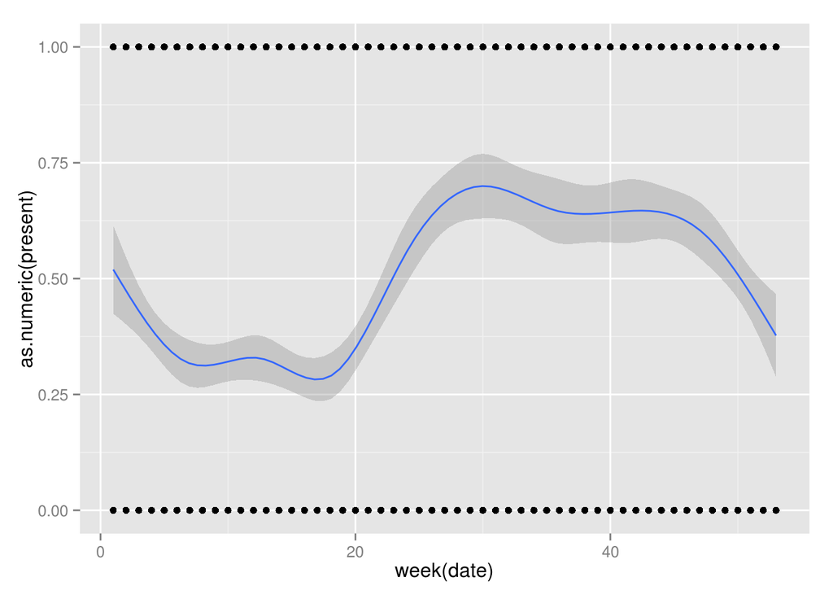

```r
pre.abs.year.aco <-  pres.abs.year (start.date = min (aco.week$date.week),
                            end.date = max (aco.week$date.week),
                            sightings = aco.week$ecocean,
                            dates = aco.week$date.week)

ggplot(pre.abs.year.aco, aes (x = week (date), y = as.numeric (present))) + geom_point() + geom_smooth()
```

```
## geom_smooth: method="auto" and size of largest group is >=1000, so using gam with formula: y ~ s(x, bs = "cs"). Use 'method = x' to change the smoothing method.
```

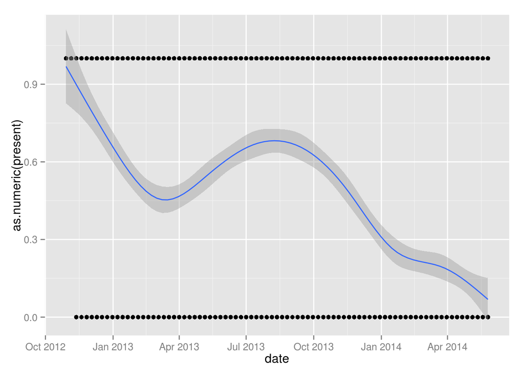

```r
ggplot(pre.abs.year.aco, aes (x = date, y = as.numeric (present))) + geom_point() + geom_smooth()
```

We next have to delete the observations from sharks known to have lost their tags.

```r
pre.abs.year.aco <- ddply (pre.abs.year.aco, "id", function (x, TAG.LOST){
  for (i in 1:length (levels (TAG.LOST$id))){
    if (as.character (TAG.LOST$id[i]) == as.character (first (x$id))){
      x <- filter (x, date < TAG.LOST$date[i])
      }
    }
  return (x)
  }, TAG.LOST = TAG.LOST) %>% tbl_df()
```

Next we should merge the precense absence data with the shark specific data

```r
names (pre.abs.year.aco)[3] <- "ecocean"
pre.abs.year.aco <- left_join (pre.abs.year.aco, select (ws.tags, ecocean, sex, size, batch))
```

It turns out it looks quite similar to the date.2 field in the previous model…

```
## geom_smooth: method="auto" and size of largest group is >=1000, so using gam with formula: y ~ s(x, bs = "cs"). Use 'method = x' to change the smoothing method.
## geom_smooth: method="auto" and size of largest group is >=1000, so using gam with formula: y ~ s(x, bs = "cs"). Use 'method = x' to change the smoothing method.
```

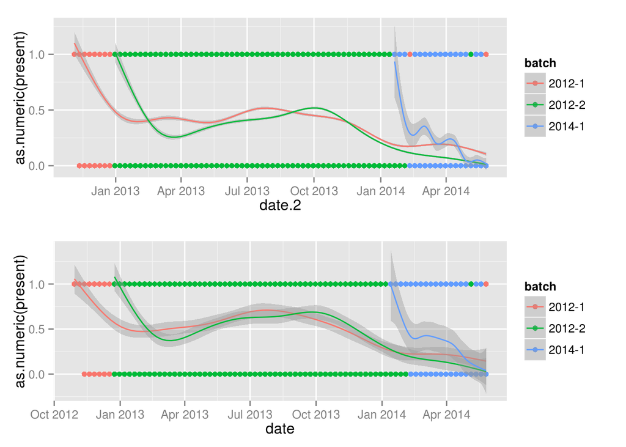

```r
p1 <- ggplot(PADet.comb.2, aes (x = date.2, y = as.numeric (present), colour = batch)) + geom_point() + geom_smooth()

p2 <- ggplot(pre.abs.year.aco, aes (x = date, y = as.numeric (present), colour = batch)) + geom_point() + geom_smooth()

multiplot (p1, p2)
```

```
## geom_smooth: method="auto" and size of largest group is >=1000, so using gam with formula: y ~ s(x, bs = "cs"). Use 'method = x' to change the smoothing method.
## geom_smooth: method="auto" and size of largest group is >=1000, so using gam with formula: y ~ s(x, bs = "cs"). Use 'method = x' to change the smoothing method.
```

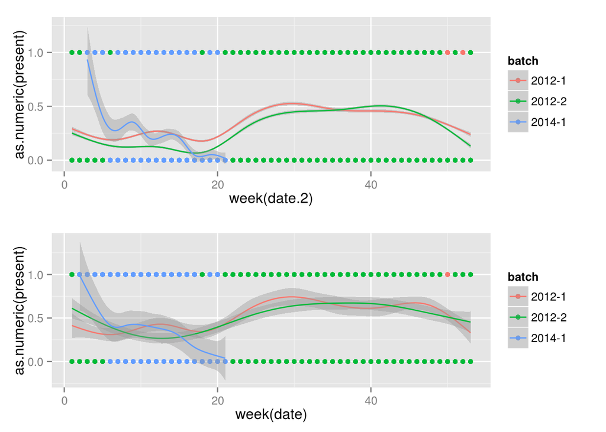

```r
p1 <- ggplot(PADet.comb.2, aes (x = week (date.2), y = as.numeric (present), colour = batch)) + geom_point() + geom_smooth()

p2 <- ggplot(pre.abs.year.aco, aes (x = week (date), y = as.numeric (present), colour = batch)) + geom_point() + geom_smooth()

multiplot (p1, p2)
```

It’s worth to revisit the combinatory data.

## Combined model

### Acoustic data

As opposed as before, we’ll calculate effort for date.2 and use date.1 only as a random effect. First we’ll delete observations of sharks known to have lost their tags.

```r
PADet.comb.2 <- ddply (PADet.comb.2, "ecocean", function (x, TAG.LOST){
  for (i in 1:length (levels (TAG.LOST$id))){
    if (as.character (TAG.LOST$id[i]) == as.character (first (x$ecocean))){
      x <- filter (x, date.2 < TAG.LOST$date[i], date.1 < TAG.LOST$date[i])
      }
    }
  return (x)
  }, TAG.LOST = TAG.LOST) %>% tbl_df()
```

```r
pres <- ddply (PADet.comb.2, "date.2", function (x, times.in){
  # Generate weekly approximations
  times.in <- mutate (times.in, w.date.in = cut (date.in, 'week'),
                      w.date.out = cut (date.out, 'week'))
    stations.listening <- filter (times.in, x$date.2[1] >= as.Date (w.date.in), x$date.2[1] <= as.Date (w.date.out)) %>%
      select (station) %>%
      unique()
  y <- data.frame (configuration = do.call (paste, as.list(stations.listening$station)),
                   nStations = nrow (stations.listening))
    return (y)
  }, times.in = times.in)

PADet.comb.2 <- inner_join (PADet.comb.2, pres)
```

Generate models

```r
# Base simple model
mb1 <- gamm (present ~ s (week.2, bs = "cc") + s (lag, bs = "cr") + sex + size, family = "binomial", data = PADet.comb.2)
```

Analyze the residuals

```r
# Save the residuals
rb01 <- residuals (mb1$gam, type = "pearson")
# Plot residuals against variables
ggplot (PADet.comb.2) + geom_boxplot (aes (y = rb01, x = ecocean))
# Evidence of heteogeneous variance per shark
ggplot (PADet.comb.2) + geom_boxplot (aes (y = rb01, x = batch))
# Evidence of heterogeneous variance per batch
ggplot (PADet.comb.2) + geom_boxplot (aes (y = rb01, x = as.factor(date.1))) + coord_flip()
# Evidence of heterogeneous variance per start date
PARes <- PADet.comb ; PARes$res <- md01
```

Add random components

```r
PADet.comb.2 <- mutate (PADet.comb.2, date.random = (as.numeric (date.1) - as.numeric (min (date.1))) / 7, date.id = paste (date.1, ecocean))
PADet.comb.2$date.random <- as.factor (PADet.comb.2$date.random)
PADet.comb.2$date.id <- as.factor (PADet.comb.2$date.id)
```

```r
# Only shark
mb02 <- gamm (formula = formula (present ~ s (week.2, bs = "cc") + s (lag, bs = "cr") + sex + size + nStations), data = PADet.comb.2, family = "binomial", gamma = 1.4, random=list(ecocean=~1))
# Only date into shark
mb03 <- gamm (formula = formula (present ~ s (week.2, bs = "cc") + s (lag, bs = "cr") + sex + size + nStations), data = PADet.comb.2, family = "binomial", gamma = 1.4, random=list(ecocean=~1, date.random = ~1))
# Shark and date combin
mb04 <- gamm (formula = formula (present ~ s (week.2, bs = "cc") + s (lag, bs = "cr") + sex + size + nStations), data = PADet.comb.2, family = "binomial", gamma = 1.4, random=list(date.id=~1))

intervals (mb02$lme, which = "var-cov")
intervals (mb03$lme, which = "var-cov")
intervals (mb04$lme, which = "var-cov")
```

Both mb03 and mb04 have valid variance covariance matrices, the most logical is mb03.

```r
PADet.comb.2<- mutate (PADet.comb.2, lag.corr <- lag / 7)
```

```r
# AR1 - Only date into shark
mb05 <- gamm (formula = formula (present ~ s (week.2, bs = "cc") + s (lag, bs = "cr") + sex + size + nStations), data = PADet.comb.2, family = "binomial", gamma = 1.4, random=list(ecocean=~1, date.random = ~1), correlation =  corAR1 (form = ~ lag.corr | date.random))
# ARMA11 - Only date into shark
mb06 <- gamm (formula = formula (present ~ s (week.2, bs = "cc") + s (lag, bs = "cr") + sex + size + nStations), data = PADet.comb.2, family = "binomial", gamma = 1.4, random=list(ecocean=~1, date.random = ~1), correlation =  corARMA (form = ~ lag.corr | date.random, p = 1, q = 1))

intervals (mb05$lme, which = "var-cov")
intervals (mb06$lme, which = "var-cov")
```

The moving average component is also significant. We’ll keep the model 6

```r
# Save the residuals
rb01 <- residuals (mb06$gam, type = "pearson")
# Plot residuals against variables
ggplot (PADet.comb.2) + geom_boxplot (aes (y = rb01, x = ecocean))
# Evidence of heteogeneous variance per shark
ggplot (PADet.comb.2) + geom_boxplot (aes (y = rb01, x = batch))
# Evidence of heterogeneous variance per batch
ggplot (PADet.comb.2) + geom_boxplot (aes (y = rb01, x = as.factor(date.1))) + coord_flip()

ggplot (PADet.comb.2, aes (x = lag, y = rb01)) + geom_point (alpha = 0.5) + geom_smooth ()

ggplot (PADet.comb.2, aes (x = week.2, y = rb01)) + geom_point (alpha = 0.5) + geom_smooth ()

ggplot (PADet.comb.2, aes (x = date.2, y = rb01)) + geom_point (alpha = 0.5) + geom_smooth ()

# Evidence of heterogeneous variance per start date
PARes <- PADet.comb ; PARes$res <- md01
```

We’ll now reduce the complexity of the model by taking out covaraites that don’t explain anything

```r
mb07 <- gamm (formula = formula (present ~ s (week.2, bs = "cc") + s (lag, bs = "cr") + sex  + nStations), data = PADet.comb.2, family = "binomial", gamma = 1.4, random=list(ecocean=~1, date.random = ~1), correlation =  corARMA (form = ~ lag.corr | date.random, p = 1, q = 1))
mb08 <- gamm (formula = formula (present ~ s (week.2, bs = "cc") + s (lag, bs = "cr") + size + nStations), data = PADet.comb.2, family = "binomial", gamma = 1.4, random=list(ecocean=~1, date.random = ~1), correlation =  corARMA (form = ~ lag.corr | date.random, p = 1, q = 1))
mb09 <- gamm (formula = formula (present ~ s (week.2, bs = "cc") + s (lag, bs = "cr") + nStations), data = PADet.comb.2, family = "binomial", gamma = 1.4, random=list(ecocean=~1, date.random = ~1), correlation =  corARMA (form = ~ lag.corr | date.random, p = 1, q = 1))
```

```r
models.acoustic <- vector ("list", 0)
models.acoustic[[1]] <- parse (text = "gamm (present ~ s (week.2, bs = 'cc') + s (lag, bs = 'cr') + sex + size, family = 'binomial', data = PADet.comb.2)")
models.acoustic[[2]] <- parse (text = "gamm (formula = formula (present ~ s (week.2, bs = 'cc') + s (lag, bs = 'cr') + sex + size + nStations), data = PADet.comb.2, family = 'binomial', gamma = 1.4, random=list(ecocean=~1))")
models.acoustic[[3]] <- parse (text = "gamm (formula = formula (present ~ s (week.2, bs = 'cc') + s (lag, bs = 'cr') + sex + size + nStations), data = PADet.comb.2, family = 'binomial', gamma = 1.4, random=list(ecocean=~1, date.random = ~1))")
models.acoustic[[4]] <- parse (text = "gamm (formula = formula (present ~ s (week.2, bs = 'cc') + s (lag, bs = 'cr') + sex + size + nStations), data = PADet.comb.2, family = 'binomial', gamma = 1.4, random=list(date.id=~1))")
models.acoustic[[5]] <- parse (text = "gamm (formula = formula (present ~ s (week.2, bs = 'cc') + s (lag, bs = 'cr') + sex + size + nStations), data = PADet.comb.2, family = 'binomial', gamma = 1.4, random=list(ecocean=~1, date.random = ~1), correlation =  corAR1 (form = ~ lag.corr | date.random))")
models.acoustic[[6]] <- parse (text = "gamm (formula = formula (present ~ s (week.2, bs = 'cc') + s (lag, bs = 'cr') + sex + size + nStations), data = PADet.comb.2, family = 'binomial', gamma = 1.4, random=list(ecocean=~1, date.random = ~1), correlation =  corARMA (form = ~ lag.corr | date.random, p = 1, q = 1))")
models.acoustic[[7]] <- parse (text = "gamm (formula = formula (present ~ s (week.2, bs = 'cc') + s (lag, bs = 'cr') + sex  + nStations), data = PADet.comb.2, family = 'binomial', gamma = 1.4, random=list(ecocean=~1, date.random = ~1), correlation =  corARMA (form = ~ lag.corr | date.random, p = 1, q = 1))")
models.acoustic[[8]] <- parse (text = "gamm (formula = formula (present ~ s (week.2, bs = 'cc') + s (lag, bs = 'cr') + size + nStations), data = PADet.comb.2, family = 'binomial', gamma = 1.4, random=list(ecocean=~1, date.random = ~1), correlation =  corARMA (form = ~ lag.corr | date.random, p = 1, q = 1))")
models.acoustic[[9]] <- parse (text = "gamm (formula = formula (present ~ s (week.2, bs = 'cc') + s (lag) + nStations), data = PADet.comb.2, family = 'binomial', gamma = 1.4, random=list(ecocean=~1, date.random = ~1), correlation =  corARMA (form = ~ lag.corr | date.random, p = 1, q = 1))")

eval.models.acoustic <- llply (models.acoustic, eval, .pararell = TRUE)
```

### Visual data

```r
# Read full data set
enc.details <- read.csv ("../Raw Data/Encounters_AllDetails_20140721.csv") %>% tbl_df () %>%
  mutate (ecocean = Marked.Individual, sex = Sex, size = Length..m.) %>%
  select (ecocean, sex, size)
levels (enc.details$sex) <- c (NA, "F", "M")
# Make a summary per shark
shark.details <- ddply (enc.details, "ecocean", function (x){
  y <- data.frame (size = mean (x$size, na.rm = TRUE),  # The mean size
                   sex = x$sex[!is.na (x$sex)][1])  # The first non NA sex
  y$sex <- as.character (y$sex)
  y$sex[is.na(y$sex)] <- "UK"
  return (y)
}) %>% tbl_df ()
# Read socprog edited data set, select only Mafia encounters, correct dates and IDs
enc.socprog <- read.csv ("../Raw Data/Ecounters_socprog_20140721.csv") %>%
  tbl_df () %>%
  filter (LocationID == "4b") %>%
  mutate (date = as.POSIXct (Date, format = "%m/%d/%y %H:%M") %>% as.Date (),
          ecocean = gsub('^(.{2})(.*)$', '\\1-\\2', ID)) %>%
  select (date, ecocean)

# Read survey data
SURVEYS <- read.csv ("../Raw Data/Surveys_20140721.csv")
SURVEYS$START.TIME <- as.POSIXct (with (SURVEYS, paste (DATE, START.TIME)), format = "%d-%b-%y %H:%M",  tz = "Africa/Dar_es_Salaam")
SURVEYS$END.TIME <- as.POSIXct (with (SURVEYS, paste (DATE, END.TIME)), format = "%d-%b-%y %H:%M",  tz = "Africa/Dar_es_Salaam")
SURVEYS$DATE <- as.Date (SURVEYS$DATE, format ='%d-%b-%y')
SURVEYS$DURATION <- with (SURVEYS, END.TIME-START.TIME)
SURVEYS$DURATION[is.na (SURVEYS$DURATION)] <- round (mean (SURVEYS$DURATION, na.rm = TRUE))

enc.socprog <- rbind (enc.socprog, data.frame (date = SURVEYS$DATE, ecocean = "XXX" )) %>%
  mutate (date.week = cut (date, 'week') %>% as.Date ())

enc.week <- ddply (enc.socprog, "date.week", function (det){
  sharks <- !duplicated (det$ecocean)
  per.week <- data.frame (ecocean = det$ecocean[sharks])
}) %>% tbl_df () %>%
  left_join (shark.details)
enc.week$sex[is.na(enc.week$sex)] <- "UK"
```

Now we calculate the precense absense response variable

```r
# For all encounters
PAEnc.comb.all <- pres.abs.lag.2 (min (SURVEYS$DATE), max (SURVEYS$DATE), enc.week$ecocean, enc.week$date) %>%
  filter (id != "XXX")

# Only for tagged sharks
enc.week.tagged <- filter (enc.week, ecocean %in% ws.tags$ecocean | ecocean == "XXX")
PAEnc.comb.tag <- pres.abs.lag.2 (min (SURVEYS$DATE), max (SURVEYS$DATE), enc.week.tagged$ecocean, enc.week.tagged$date) %>%
  filter (id != "XXX")
```

Explore the data

```r
ggplot(PAEnc.comb.all, aes (x = date.2, y = as.numeric (present))) + geom_point() + geom_smooth()

ggplot(PAEnc.comb.tag, aes (x = date.2, y = as.numeric (present))) + geom_point() + geom_smooth()

ggplot(PAEnc.comb.all, aes (x = week (date.2), y = as.numeric (present))) + geom_point() + geom_smooth()
ggplot(PAEnc.comb.tag, aes (sx = week (date.2), y = as.numeric (present))) + geom_point() + geom_smooth()

ggplot(PAEnc.comb.all, aes (x = lag, y = as.numeric (present))) + geom_point() + geom_smooth()

ggplot(PAEnc.comb.tag, aes (x = lag, y = as.numeric (present))) + geom_point() + geom_smooth()
```

Looks like it’s better to use the only tagged sharks info

```r
names(PAEnc.comb.tag)[5] <- "ecocean"
PAEnc.comb.tag <- left_join (PAEnc.comb.tag, shark.details) %>%
  mutate (sex = factor (sex))
# Impute a size for sharks without a size
PAEnc.comb.tag$size.imp <- mean (PAEnc.comb.tag$size, na.rm = TRUE)
PAEnc.comb.tag$size.imp[!is.na (PAEnc.comb.tag$size)] <- PAEnc.comb.tag$size[!is.na (PAEnc.comb.tag$size)]
```

Add effort per week

```r
SURVEYS <- mutate (SURVEYS, date.week = cut (DATE, "week") %>% as.Date ())
# Weekly summary of survey effort
surveys.week <- tbl_df (SURVEYS) %>%
  mutate (duration = as.numeric (DURATION)) %>%
  select (-(DURATION)) %>%
  group_by (date.week) %>%
  summarise (observers = mean (SNORKELERS, na.rm = TRUE),
             hours = sum (as.numeric (duration)) / 60) %>%
  mutate (date.2 = date.week) %>%
  select (-(date.week))
# Merge with the data frame and create
PAEnc.comb.tag <- inner_join (PAEnc.comb.tag, surveys.week) %>%
  mutate (week.1 = week (date.1),
          week.2 = week (date.2),
          date.random = (as.numeric (date.1) - as.numeric (min (date.1))) / 7,
          date.id = paste (date.1, ecocean))
PAEnc.comb.tag$date.random <- as.factor (PAEnc.comb.tag$date.random)
PAEnc.comb.tag$date.id <- as.factor (PAEnc.comb.tag$date.id)
```

Create models

```r
me01 <- gamm (present ~ s (week.2, bs = "cc") + s (lag, bs = "cr") + sex + size + hours, family = "binomial", data = PAEnc.comb.tag)
```

```r
# Only shark
me02 <- gamm (present ~ s (week.2, bs = "cc") + s (lag, bs = "cr") + sex + size + hours, family = "binomial", data = PAEnc.comb.tag, random=list(ecocean=~1))
# Date into shark
me03 <- gamm (present ~ s (week.2, bs = "cc") + s (lag, bs = "cr") + sex + size + hours, family = "binomial", data = PAEnc.comb.tag, random=list(ecocean=~1, date.random = ~1), niterPQL = 10000)
# Date and shark combined
me04 <- gamm (present ~ s (week.2, bs = "cc") + s (lag, bs = "cr") + sex + size + hours, family = "binomial", data = PAEnc.comb.tag, random=list(date.id=~1), niterPQL = 10000)

intervals (me02$lme, which = "var-cov")
intervals (me03$lme, which = "var-cov")
intervals (me04$lme, which = "var-cov")
```

There is probably not enough data to use date.1 as a random effect. Now we try the correlation

```r
PAEnc.comb.tag <- mutate (PAEnc.comb.tag, lag.corr = lag / 7)
```

```r
# AR1 -  into shark

me05 <- gamm (present ~ s (week.2, bs = "cc") + s (lag, bs = "cr") + sex + size + hours, family = "binomial", data = PAEnc.comb.tag, random=list(ecocean=~1), correlation =  corAR1 (form = ~ lag.corr | date.random))
# ARMA11 -into shark
me06 <- gamm (present ~ s (week.2, bs = "cc") + s (lag, bs = "cr") + sex + size + hours, family = "binomial", data = PAEnc.comb.tag, random=list(ecocean=~1), correlation =  corARMA (form = ~ lag.corr | date.random, p = 1, q = 1))

intervals (me05$lme, which = "var-cov")
intervals (me06$lme, which = "var-cov")
```

Not enough information to include an auto-correlation term. Now we reduce the model. And discard non-significant variables. We’ll stick to the random structure of model 2

```r
me07 <- gamm (present ~ s (week.2, bs = "cc") + s (lag, bs = "cr") + sex  + hours, family = "binomial", data = PAEnc.comb.tag, random=list(ecocean=~1))
me08 <- gamm (present ~ s (week.2, bs = "cc") + s (lag, bs = "cr") + size  + hours, family = "binomial", data = PAEnc.comb.tag, random=list(ecocean=~1))
me09 <- gamm (present ~ s (week.2, bs = "cc") + s (lag, bs = "cr") + hours, family = "binomial", data = PAEnc.comb.tag, random=list(ecocean=~1))
```

## Model results

Now we just chose here each of the best models and explore it’s implications.

```r
model.acoustic <- gamm (formula = formula (present ~ s (week.2, bs = "cc") + s (lag, bs = "cr") + nStations), data = PADet.comb.2, family = "binomial", gamma = 1.4, random=list(ecocean=~1, date.random = ~1), correlation =  corARMA (form = ~ lag.corr | date.random, p = 1, q = 1))
```

```
##
##  Maximum number of PQL iterations:  20
```

```
## iteration 1
## iteration 2
## iteration 3
## iteration 4
## iteration 5
## iteration 6
## iteration 7
## iteration 8
## iteration 9
```

```r
model.visual <- gamm (present ~ s (week.2, bs = "cc") + s (lag, bs = "cr") + hours, family = "binomial", data = PAEnc.comb.tag, random=list(ecocean=~1))
```

```
##
##  Maximum number of PQL iterations:  20
```

```
## iteration 1
## iteration 2
## iteration 3
## iteration 4
## iteration 5
## iteration 6
## iteration 7
## iteration 8
## iteration 9
## iteration 10
## iteration 11
## iteration 12
## iteration 13
```

Now we make a simulation comparing both datasets

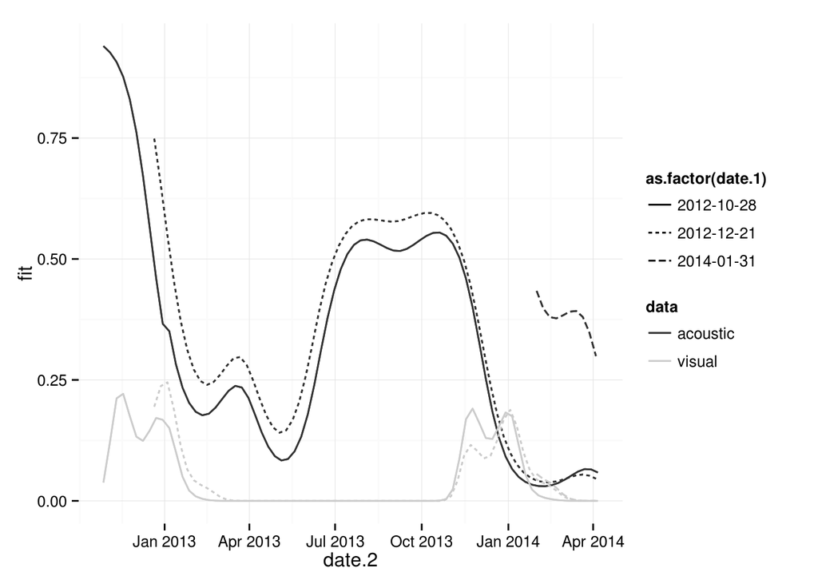

```r
# All tagging dates
first.date <- (tbl_df (ws.tags) %>% group_by (batch) %>% summarise (initial.dates = median (date.tag) %>% as.Date ()) %>% select (initial.dates))$initial.dates
last.date <- as.Date ("2014-04-07")
pred.date <- foreach (i=1:length(first.date), .combine = rbind) %do%{
  expand.grid (date.1 = first.date[i],
                     date.2 = seq (first.date[i], last.date, by ="week"),
                     hours = max (PAEnc.comb.tag$hours),
                     nStations = max (PADet.comb.2$nStations)) %>%
    mutate (week.2 = week (date.2),
            lag = as.numeric (date.2) - as.numeric (date.1)) %>%
    tbl_df()
}
pred.date <- cbind (pred.date, predict (model.acoustic$gam, pred.date, type = "response", se.fit = TRUE))
pred.date <- cbind (pred.date, predict (model.visual$gam, pred.date, type = "response", se.fit = TRUE)) %>% tbl_df()
names (pred.date)[7:10] <- c("aco.fit", "aco.se", "vis.fit", "vis.se")

# Melt data prediction data frame
pred.date <- rbind (pred.date, pred.date) %>% tbl_df () %>%
  mutate (fit = c (pred.date$aco.fit, pred.date$vis.fit),
          se = c (pred.date$aco.se, pred.date$vis.se),
          data = rep (c ("acoustic", "visual"), each = nrow (pred.date)))

# Plot probabilities
ggplot(pred.date, aes (x = date.2)) +
  geom_line (aes (y = fit, colour = data, linetype = as.factor (date.1)))  +
  geom_line (aes (y = fit, colour = data, linetype = as.factor (date.1)))  +
  theme_minimal () +
  #geom_ribbon (aes (ymin = fit - se, ymax = fit + se, fill = data, linetype = as.factor (date.1)), alpha = 0.3) + geom_ribbon (aes (ymin = fit - se, ymax = fit + se, fill = data, linetype = as.factor (date.1)), alpha = 0.3) +
  scale_colour_grey () + scale_fill_grey ()
```

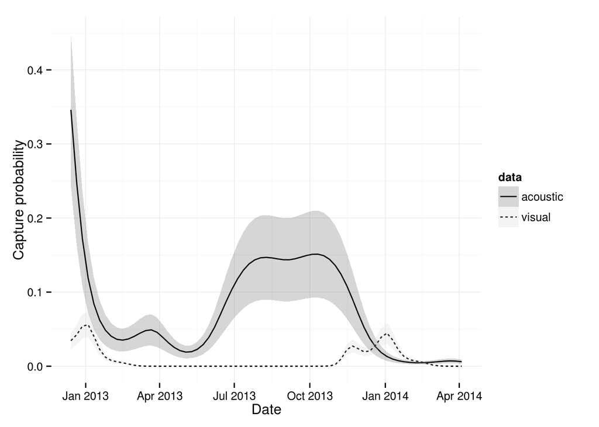

```r
# Median tagging date
first.date <- median (ws.tags$date.tag) %>% as.Date () -1
last.date <- as.Date ("2014-04-07")
pred.date <- foreach (i=1:length(first.date), .combine = rbind) %do%{
  expand.grid (date.1 = first.date[i],
                     date.2 = seq (first.date[i], last.date, by ="week"),
                     hours = median (PAEnc.comb.tag$hours),
                     nStations = median (PADet.comb.2$nStations)) %>%
    mutate (week.2 = week (date.2),
            lag = as.numeric (date.2) - as.numeric (date.1)) %>%
    tbl_df()
}
pred.date <- cbind (pred.date, predict (model.acoustic$gam, pred.date, type = "response", se.fit = TRUE))
pred.date <- cbind (pred.date, predict (model.visual$gam, pred.date, type = "response", se.fit = TRUE)) %>% tbl_df()
names (pred.date)[7:10] <- c("aco.fit", "aco.se", "vis.fit", "vis.se")

# Melt data prediction data frame
pred.date <- rbind (pred.date, pred.date) %>% tbl_df () %>%
  mutate (fit = c (pred.date$aco.fit, pred.date$vis.fit),
          se = c (pred.date$aco.se, pred.date$vis.se),
          data = rep (c ("acoustic", "visual"), each = nrow (pred.date)))


# Plot probabilities for just one initial date
ggplot(pred.date, aes (x = date.2)) +
  geom_line (aes (y = fit, linetype = data))  +
  theme_minimal () +
  geom_ribbon (aes (ymin = fit - se, ymax = fit + se, fill = data), alpha = 0.2) +
  scale_colour_grey () + scale_fill_grey () +
  xlab ("Date") + ylab ("Capture probability")
```

Now we make a comparison of for year and lag

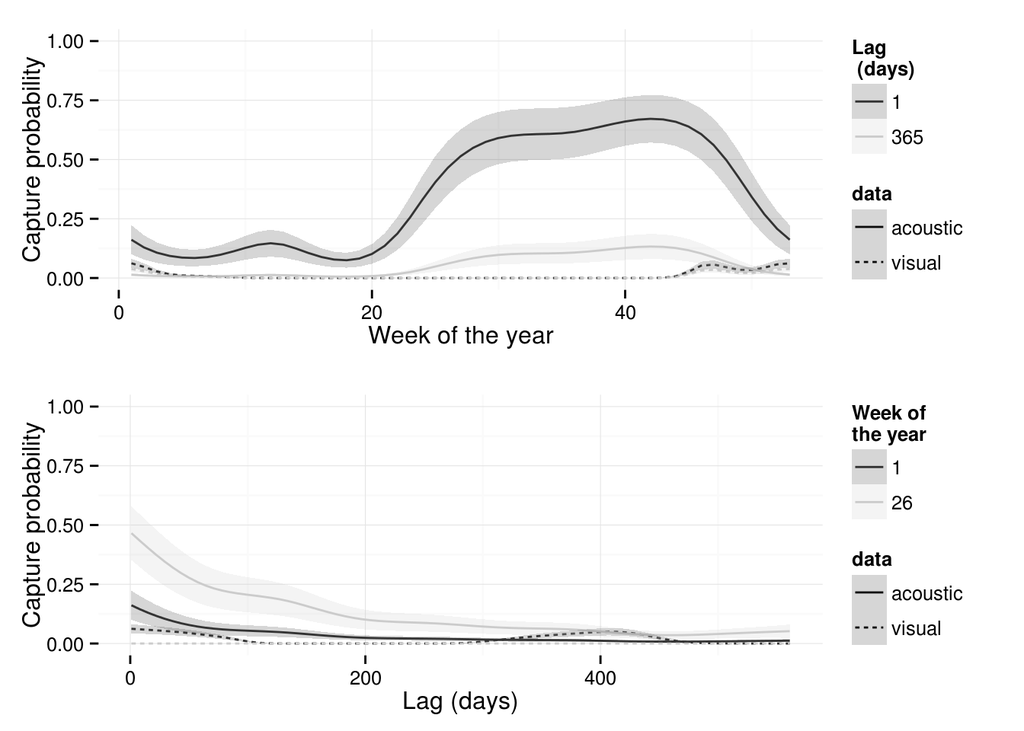

```r
pred.yl <- expand.grid (week.2 = 1:53,
                        lag = seq (1, 567, by = 7),
                        hours = median (PAEnc.comb.tag$hours),
                        nStations = median (PADet.comb.2$nStations))
pred.yl <- cbind (pred.yl, predict (model.acoustic$gam, pred.yl, type = "response", se.fit = TRUE))
pred.yl <- cbind (pred.yl, predict (model.visual$gam, pred.yl, type = "response", se.fit = TRUE)) %>% tbl_df()
names (pred.yl)[5:8] <- c("aco.fit", "aco.se", "vis.fit", "vis.se")

# Melt data prediction data frame
pred.yl <- rbind (pred.yl, pred.yl) %>% tbl_df () %>%
  mutate (fit = c (pred.yl$aco.fit, pred.yl$vis.fit),
          se = c (pred.yl$aco.se, pred.yl$vis.se),
          data = rep (c ("acoustic", "visual"), each = nrow (pred.yl)))

# Year plot
p1 <- ggplot (filter (pred.yl, lag == min (lag) | lag == 365), aes (x = week.2)) + geom_line (aes (y = fit, colour = as.factor (lag), linetype = data)) + theme_minimal () +
  geom_ribbon (aes (ymin = fit-se, ymax = fit+se, fill = as.factor (lag), linetype = data), alpha = 0.2)+
  scale_colour_grey (name = "Lag\n (days)") + scale_fill_grey (name = "Lag\n (days)") +
  xlab ("Week of the year") + ylab ("Capture probability") + ylim (0,1)

# Lag plot
p2 <- ggplot (filter (pred.yl, week.2 %in% round (seq (1,53/2, length.out = 2), week.2 != 1)), aes (x = lag)) + geom_line (aes (y = fit, colour = as.factor (week.2), linetype = data)) + theme_minimal () +
  geom_ribbon (aes (ymin = fit-se, ymax = fit+se, fill = as.factor (week.2), linetype = data), alpha = 0.2) +
  scale_colour_grey (name = "Week of\nthe year") + scale_fill_grey (name = "Week of\nthe year") +
  xlab ("Lag (days)") + ylab ("Capture probability") + ylim (0,1)

multiplot (p1, p2)
```

Now we will try 3D plots

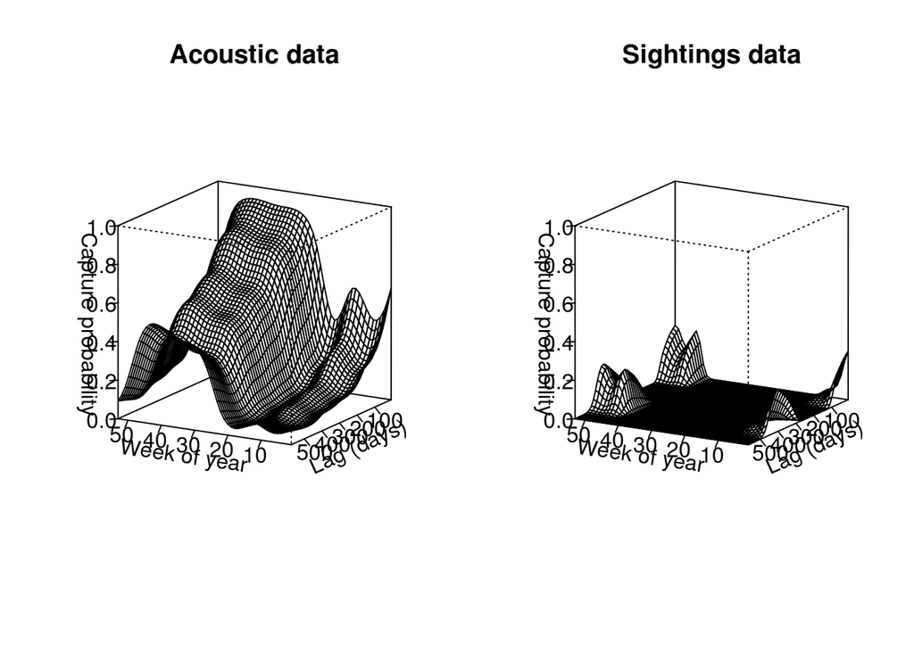

```r
par (mfrow  = c (1,2))
vis.gam (model.acoustic$gam, view = c ("week.2", "lag"), cond = list (                                                                  nStations = max (PADet.comb.2$nStations)), type = "response", theta = 90+30+90, phi =15, r = 1000, ticktype = "detailed", zlim = c (0,1), color = "bw", n.grid = 50, main = "Acoustic data", xlab = "Week of year", ylab = "Lag (days)", zlab = "Capture probability")

vis.gam (model.visual$gam, view = c ("week.2", "lag"), cond = list (                                                                      hours = max (PAEnc.comb.tag$hours)), type = "response", theta = 90+30+90, phi =15, r = 1000, ticktype = "detailed", zlim = c (0,1), color = "bw", n.grid = 50, main = "Sightings data", xlab = "Week of year", ylab = "Lag (days)", zlab = "Capture probability")
```

Now we do interval plots for the basic models. We leave for later

```
## ymax not defined: adjusting position using y instead
```

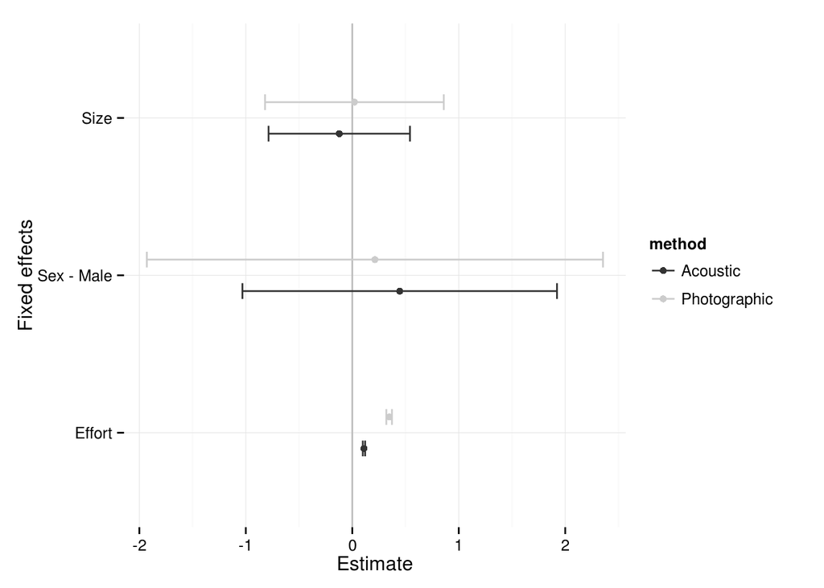

```r
int.fixed.aco <- intervals (mb06$lme)$fixed %>% as.data.frame () %>%
  mutate (variables = c ("Intercept", "Sex - Male", "Sex - UK", "Size", "Effort", "Lag"), method = "Photographic")

int.fixed.vis <- rbind (intervals (me07$lme)$fixed %>% as.data.frame (), (intervals (me08$lme)$fixed %>% as.data.frame ())[2, ]) %>%
  mutate (variables = c ("Intercept", "Sex - Male", "Effort", "Lag", "Size"), method = "Acoustic")

int.fixed <- rbind (int.fixed.aco, int.fixed.vis)

ggplot (filter (int.fixed, variables != "Lag", variables != "Intercept", variables != "Sex - UK"), aes (x = variables)) +
  geom_hline (aes(yintercept = 0), colour = "gray") +
  geom_point (aes (y = est., colour = method), position = position_dodge (width = 0.4), ymax = 0.2, stat = "identity") +
  geom_errorbar (aes (y = est., ymin = lower, ymax = upper, colour = method), width = 0.2, position = position_dodge (width = 0.4), stat = "identity") +
  coord_flip () + theme_minimal () + scale_color_grey () + ylab ("Estimate") + xlab ("Fixed effects")
```

Now we try to select just the smooth components

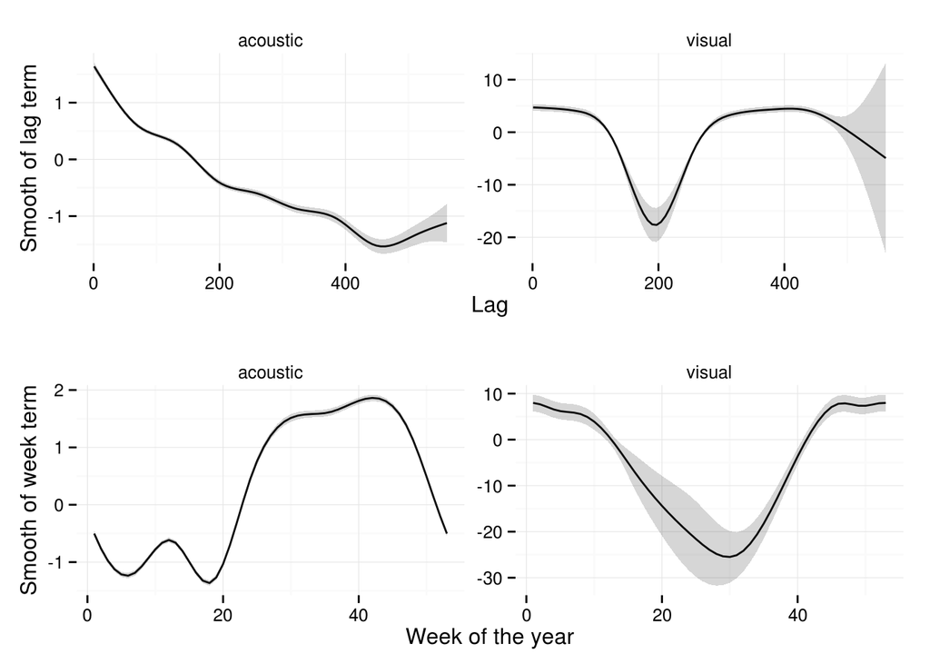

```r
pred.smoo.lag <- data.frame (lag = seq (1, 567, by = 7), week.2 = 1, hours = 1, nStations = 1)
pred.smoo.lag$aco.fit <- predict (model.acoustic$gam, newdata = pred.smoo.lag, type = "terms", se.fit = TRUE)$fit[, 3]
pred.smoo.lag$aco.se <- predict (model.acoustic$gam, newdata = pred.smoo.lag, type = "terms", se.fit = TRUE)$se[, 3]
pred.smoo.lag$vis.fit <- predict (model.visual$gam, newdata = pred.smoo.lag, type = "terms", se.fit = TRUE)$fit[, 3]
pred.smoo.lag$vis.se <- predict (model.visual$gam, newdata = pred.smoo.lag, type = "terms", se.fit = TRUE)$se[, 3]

# Melt data prediction data frame
pred.smoo.lag <- rbind (pred.smoo.lag, pred.smoo.lag) %>% tbl_df () %>%
  mutate (fit = c (pred.smoo.lag $aco.fit, pred.smoo.lag $vis.fit),
          se = c (pred.smoo.lag $aco.se, pred.smoo.lag $vis.se),
          data = rep (c ("acoustic", "visual"), each = nrow (pred.smoo.lag )))

p1 <- ggplot (pred.smoo.lag, aes (x = lag)) + geom_line (aes (y = fit)) + facet_wrap (~data , scales = "free_y") + theme_minimal () + xlab ("Lag") + ylab ("Smooth of lag term") + geom_ribbon (aes (ymin = fit-se, ymax = fit+se), alpha = 0.2)

pred.smoo.week <- data.frame (lag = 1, week.2 = seq (1, 53, by = 1), hours = 1, nStations = 1)
pred.smoo.week$aco.fit <- predict (model.acoustic$gam, newdata = pred.smoo.week, type = "terms", se.fit = TRUE)$fit[, 2]
pred.smoo.week$aco.se <- predict (model.acoustic$gam, newdata = pred.smoo.week, type = "terms", se.fit = TRUE)$se[, 2]
pred.smoo.week$vis.fit <- predict (model.visual$gam, newdata = pred.smoo.week, type = "terms", se.fit = TRUE)$fit[, 2]
pred.smoo.week$vis.se <- predict (model.visual$gam, newdata = pred.smoo.week, type = "terms", se.fit = TRUE)$se[, 2]

# Melt data prediction data frame
pred.smoo.week <- rbind (pred.smoo.week, pred.smoo.week) %>% tbl_df () %>%
  mutate (fit = c (pred.smoo.week $aco.fit, pred.smoo.week $vis.fit),
          se = c (pred.smoo.week $aco.se, pred.smoo.week $vis.se),
          data = rep (c ("acoustic", "visual"), each = nrow (pred.smoo.week )))

p2 <-  ggplot (pred.smoo.week, aes (x = week.2)) + geom_line (aes (y = fit)) + facet_wrap (~data , scales = "free_y") + theme_minimal () + geom_ribbon (aes (ymin = fit-se, ymax = fit+se), alpha = 0.2) + xlab ("Week of the year") + ylab ("Smooth of week term")

multiplot (p1, p2)
```

# Depth and distance models